# Ebio Analyzed Data Report

2021-02-15

## Introduction

This is an R Markdown document written and deployed by **Kasun Buddika** to distribute reanalyzed data from *Wheeler et al. 2020*. Developed by Gene Yeo’s group at UCSD, this novel method, CRaft-ID (CRISPR-based microRaft followed by guide RNA identification), combines pooled CRISPR–Cas9 screening with microraft array technology and high-content imaging to screen image-based phenotypes. For more details, read the paper [here](https://www.nature.com/articles/s41592-020-0826-8).

## Analysis of primer containing reads

The devised CRaft-ID approach requires a high-throughput two-step PCR-based sequencing approach to definitively identify the gRNA and hence the affected gene(s) in each microRaft. Therefore, it is important to quantify the reads originating from proper PCR amplification.

```r
library(gridExtra)
library(knitr)
library(rlang)
library(tidyverse)
```

Here are details about library sizes and the number of reads with primers in each library.

```r
primerReads <- read_csv("data/primer_Counts.csv")
names(primerReads) <-c("Dataset", "Raw_Count", "Reads_With_Primer")

knitr::kable(primerReads, caption = "Table 1. Raw and primer containing read counts")
```

Table 1. Raw and primer containing read counts

| Dataset | Raw_Count | Reads_With_Primer |
| --- | --- | --- |
| SRR10384085.fastq | 1743074 | 1412850 |
| SRR10384086.fastq | 2145764 | 1577564 |
| SRR10384087.fastq | 2349219 | 1784938 |
| SRR10384088.fastq | 2262730 | 1642230 |
| SRR10384089.fastq | 4150501 | 2480484 |
| SRR10384090.fastq | 2563695 | 2395498 |

[figure not shown]

```r
barPlotter <- function(inData, X, Y, fillColor, Title, labY){

  Y_col <- enquo(Y)
  X_col <- enquo(X)

  inData %>%
    select(c(!!X_col, !!Y_col)) %>%
    mutate(!!X_col := fct_reorder(!!X_col, !!Y_col)) %>%
    ggplot(aes(x = !!X_col, y = !!Y_col)) +
    geom_col(fill = fillColor) +
    theme_bw() +
    coord_flip() +
    ggtitle(str_glue(Title)) +
    ylab(labY) +
    scale_y_continuous(labels = scales::scientific)
}

p1 <- barPlotter(primerReads, Dataset, Raw_Count, "#D55E00", "Raw Read Count", "Read Count")
p2 <- barPlotter(primerReads, Dataset, Raw_Count, "#CC79A7", "Primer Containing Read Count", "Read Count")
grid.arrange(p1, p2, nrow=2)
```

Additionally, the following plot shows the percentage of reads with and without primer sequences.

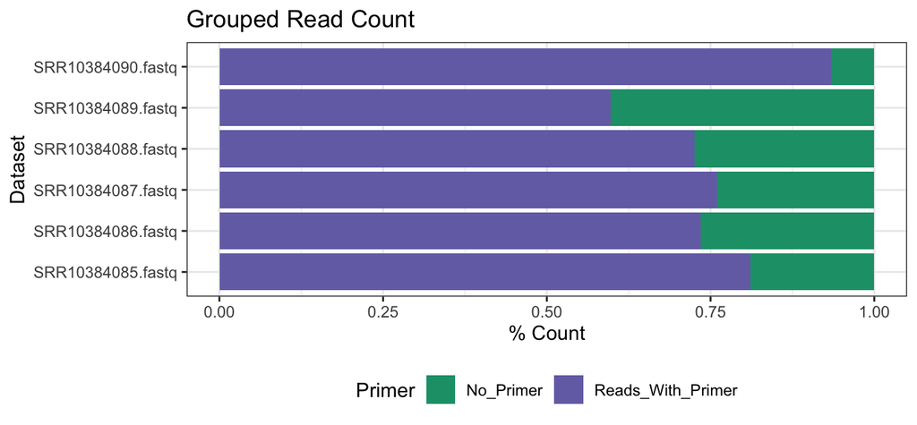

```r
rearrData <- primerReads %>%
  mutate(No_Primer = Raw_Count - Reads_With_Primer) %>%
  gather(key = Primer,
         value = Counts,
         c(Reads_With_Primer:No_Primer))

rearrData %>%
  ggplot(aes(x = Dataset, y = Counts, fill = Primer)) +
  geom_col(position="fill") +
  theme_bw() +
  scale_fill_manual(values = c("#1B9E77", "#7570B3")) +
  coord_flip() +
  ggtitle("Grouped Read Count") +
  theme(legend.position="bottom") +
  ylab("% Count")
```

### Linear regression model for predicting primer containing read number

To estimate the number of reads with primers for a given library, a linear regression model was fitted using a training data set comprised of raw and primer containing read counts from 41 libraries.

```r
training_data <- read_csv("data/training_data.csv")

fit <- lm(With_Primer ~ Raw_Count - 1, training_data)
fit
```

```
##
## Call:
## lm(formula = With_Primer ~ Raw_Count - 1, data = training_data)
##
## Coefficients:
## Raw_Count
##    0.7205
```

Summary statistics of the fitted model is given below.

```r
summary(fit)
```

```
##
## Call:
## lm(formula = With_Primer ~ Raw_Count - 1, data = training_data)
##
## Residuals:
##     Min      1Q  Median      3Q     Max
## -509950    2725    6896   18786  548343
##
## Coefficients:
##           Estimate Std. Error t value Pr(>|t|)
## Raw_Count  0.72049    0.01917   37.58   <2e-16 ***
## ---
## Signif. codes:  0 '***' 0.001 '**' 0.01 '*' 0.05 '.' 0.1 ' ' 1
##
## Residual standard error: 125300 on 40 degrees of freedom
## Multiple R-squared:  0.9725, Adjusted R-squared:  0.9718
## F-statistic:  1412 on 1 and 40 DF,  p-value: < 2.2e-16
```

The following two plots show the distribution of training data alone (left) and the fitted linear regression model (right). The model predicts that a library with 1000 total raw reads will have ~720 reads with primer sequences.

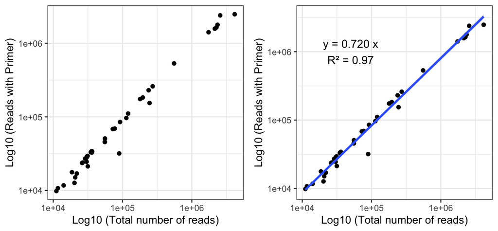

```r
p3 <- ggplot(training_data) +
  geom_point(mapping = aes(x = Raw_Count, y = With_Primer)) +
  theme_bw() +
  scale_x_log10() +
  scale_y_log10() +
  ylab("Log10 (Reads with Primer)") +
  xlab("Log10 (Total number of reads)")

p4 <- p3 +
  geom_smooth(mapping = aes(x = Raw_Count, y = With_Primer), method = "lm",
              formula=y~0+x) +
  annotate(label = sprintf("y = %.3f x\nR² = %.2f", coef(fit), summary(fit)$r.squared),
           geom = "text", x = 5e+04, y = 1e+06, size = 4)

grid.arrange(p3, p4, nrow=1)
```

## Analysis of gRNA composition in individual libraries

Next, the most frequent gRNA sequences were identified in each library. Count data are in a different file. Following plot shows the top 10 gRNAs in one of the libraries analyzed.

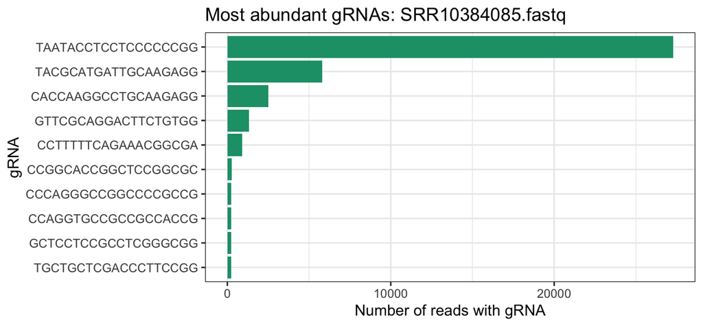

```r
gRNACounts <- read_csv("data/gRNA_Counts.csv") %>%
  select(2:8)

barPlotter <- function(inData, X, Y, fillColor){

  Y_col <- enquo(Y)
  X_col <- enquo(X)

  inData %>%
    select(c(!!X_col, !!Y_col)) %>%
    slice_max(!!Y_col, n=10) %>%
    mutate(!!X_col := fct_reorder(!!X_col, !!Y_col)) %>%
    ggplot(aes(x = !!X_col, y = !!Y_col)) +
    geom_col(fill = fillColor) +
    theme_bw() +
    coord_flip() +
    ggtitle(str_glue("Most abundant gRNAs: {quo_text(Y_col)}")) +
    ylab("Number of reads with gRNA")
}

barPlotter(gRNACounts, gRNA, SRR10384085.fastq, "#1B9E77")
```